# Lecture 7: Generating Digital Advertising

SKOC42: Digital Marketing Communication 2026

nils.holmberg@iko.lu.se

## SOSTAC:

**Tactics**

## Landing Page Design

- `Define journey endpoint before any asset`
- Design for Analysis built in from start
- Information architecture aids findability
- Persuasion: layout, typography, scent-trails
- Social proof adds independent credibility

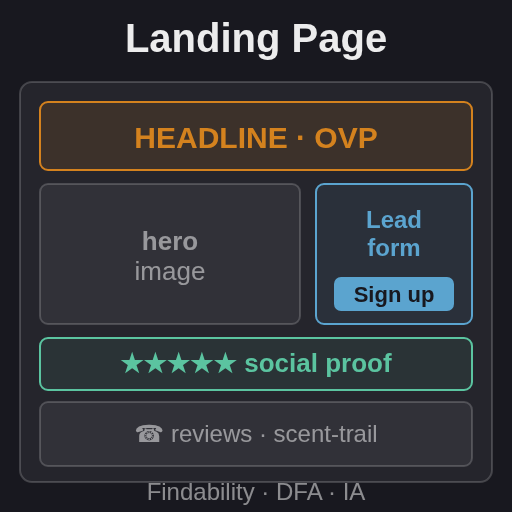

## Tracking Setup

- `LLM scaffolds HTML / CSS for fast mockups`
- GA4 via gtag.js or Google Tag Manager
- Lead form, phone number, social-proof widget
- Hotjar visualizes clickstream and exits
- UTM tags attribute leads to ad assets

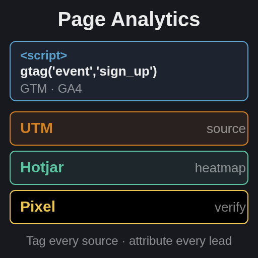

## The Big Idea

- `Central hook underpins text and visuals`
- Distinctive elements break through clutter
- Polestar positioned above Tesla as superior
- Brand alignment with existing perceptions
- Activating emotions: surprise, excitement, awe

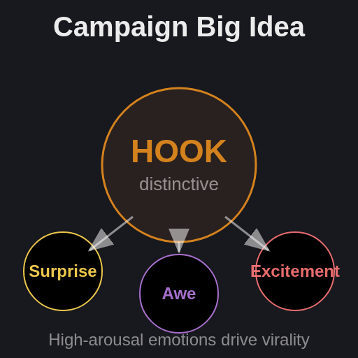

## Concept Visualization

- `Midjourney, DALL·E generate mood boards`
- Biddable strategy optimizes interaction rate
- AI sentiment pre-tests high-arousal copy
- Falcon anchors hooks to trending hashtags
- Matrix sorts entertain vs. convince assets

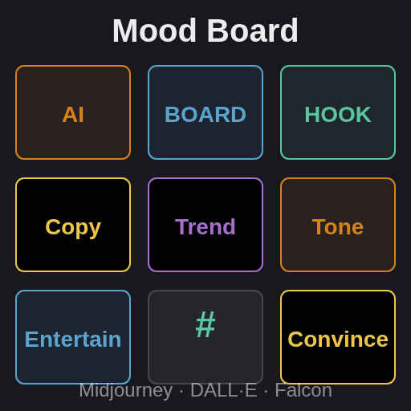

## Visual Design

- `Salience captures focal attention in clutter`
- Hemispheric neuromarketing: pictorial on the left side
- Directed gaze beats mutual for memorability
- Figure-ground keeps product as focal point
- Rich media outperforms static banners

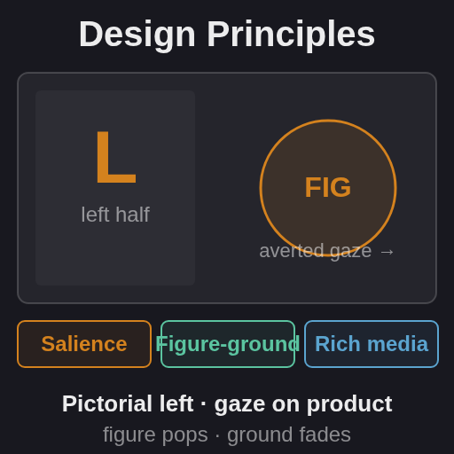

## Asset Production

- `Photoshop or Photopea refines AI base art`
- IAB sizes: Mid-Page Unit, Skyscraper, Leaderboard
- Figure-ground via contrast and sharp focus
- Left-side placement for right-brain reach
- Edit gaze toward product or CTA button

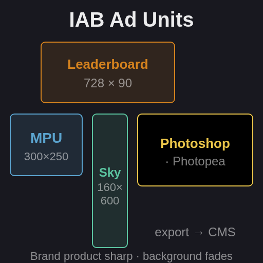

## Copywriting Essentials

- `Primary message goes in high-visibility spots`
- Tone-of-voice keeps brand character consistent
- Avoid pragmatic inferences in slogans
- Page titles, meta drive rank and click
- High-involvement asks argument-based detail

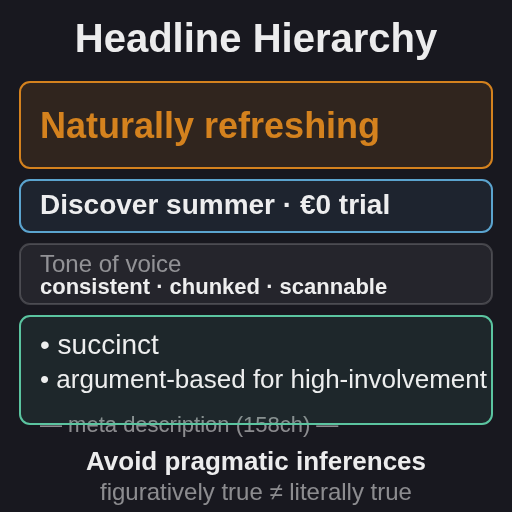

## SEO Copy Tactics

- `LLMs generate title and meta variations`
- Keyword-aligned headlines raise Quality Score
- Chunked 5–6 lines suit lean-forward reading
- Audit slogans for psychological reactance
- Detailed technical guides for high-involvement

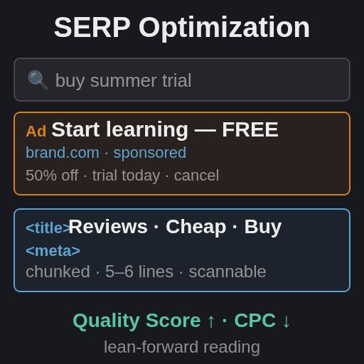

## SOSTAC:

**Actions**

## CTA Design

- `Trigger fires when motivation meets ability`
- Prominent buttons above the fold and repeated
- Action-oriented, incentivized wording wins
- Contrasting colors pop from the background
- Scent-trail reassures the right persona

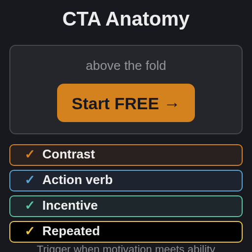

## CTA Triggers

- `High-contrast CSS · placed above the fold`
- “Start learning for FREE” beats generic copy
- Wording matches persona’s scent-trail path
- Exit-intent pop-ups serve a final offer
- CTA appears when motivation meets ability

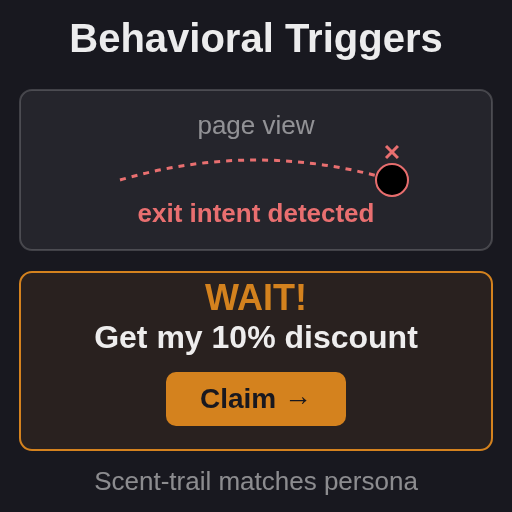

## Channel Creative

- `Paid search: small ad groups for relevance`
- Social: editorial calendar drives cadence
- Email: dynamic content keyed to profile
- Display: tailored to awareness vs. retarget
- Native: matches host editorial design

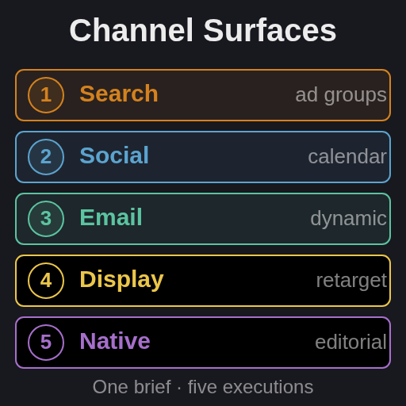

## Channel Deployment

- `Demand-Side Platforms manage Real-Time Bidding across publisher sites`
- Custom Audiences via emails or pixel data
- Mailchimp triggers welcome sequences
- Sponsored articles match top-tier styles

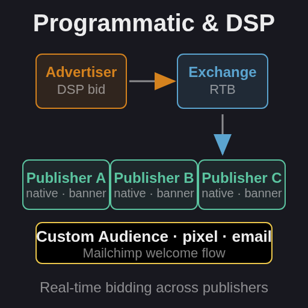

## SOSTAC:

**Control**

## Prototyping

- `Iterative refinement on audience feedback`
- Wireframes define layout before graphics
- Concept tests reveal drivers and barriers
- Expert reviews find principle deficiencies
- Mobile-first scales up to desktop later

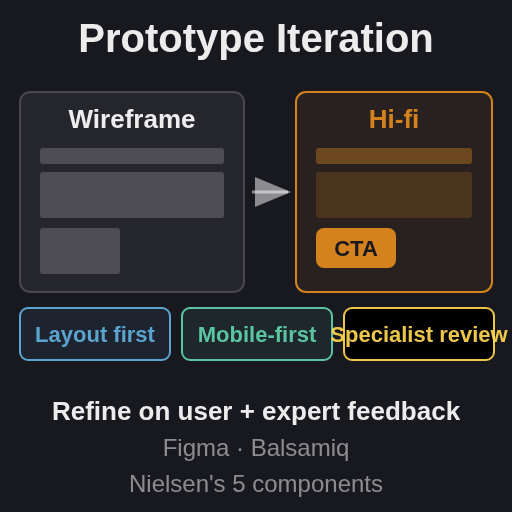

## Pre-Test Tools

- `Figma, Balsamiq blueprint information architecture`
- Nielsen’s 5 usability components guide expert reviews
- SurveyMonkey runs a pre-launch disaster check
- DevTools emulate phone and tablet sizes
- Observe 3–5 users completing top tasks

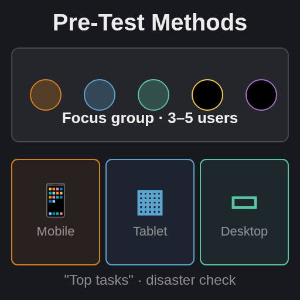

## Testing & Optimization

- `A/B serves two versions to compare performance`
- Multivariate tests find the best combination
- CRO: test, learn, refine commercial value
- Analytics adjust bids and creative in-flight
- Attribution traces multi-touch contribution

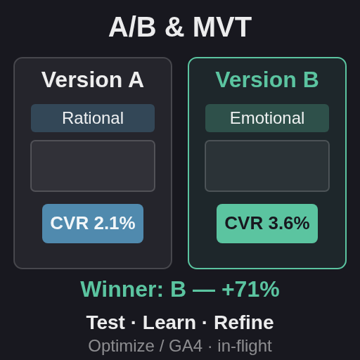

## Attribution

- `Google Optimize splits and tests significance`
- Meta Pixel Helper verifies firing on convert
- GA4 Path Exploration finds drop-out points
- Switch last-click vs. data-driven models
- Test-learn-refine loop adjusts bids in-flight

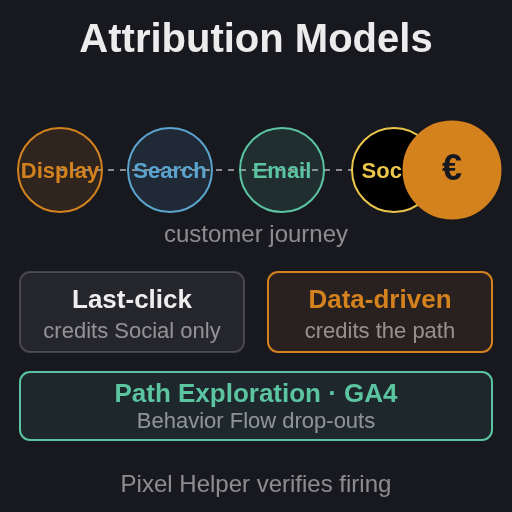

## Creative Inspiration

- `Ad campaign backends`
  - [Google Ads](https://ads.google.com/)
  - [X Business](https://ads.x.com/manager/)
- `Ad text, image generation`
  - Generative [AI](https://gemini.google.com/share/270134532a41)
  - Web-based free [photoshop](https://www.photopea.com/)
- `Exam preparation`
  - Lectures, literature [quiz](https://gemini.google.com/share/68512b4fee00)

## Digital Marketing

**Career**

## Defining the Marketer

- `Builds awareness across digital channels`
- Drives revenue and lifetime value
- Spots growth via data-driven strategy
- Balances paid acquisition with SEO
- Works the CRM, analytics, media stack

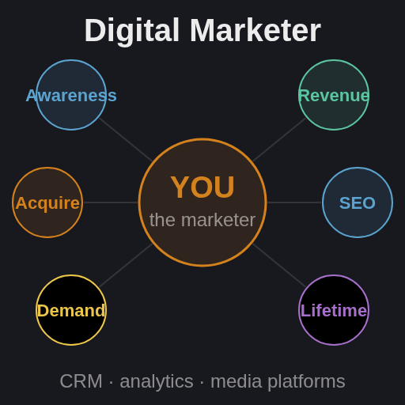

## Core Digital Skills

- `Diverse technical knowledge required`
- Switch from content to email workflows
- Go broad first · find your passion
- Soft skills balance the technical
- Adapt to constant algorithm shifts

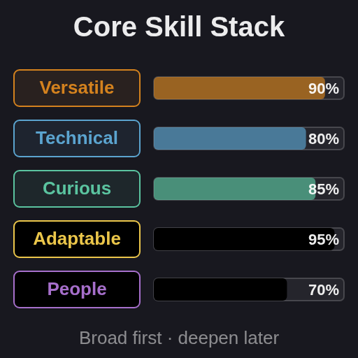

## AI & Automation

- `54% rank AI strategy the top skill`
- Automates repetitive personalization
- Prompting ChatGPT, Claude now standard
- Design email and social workflows
- Mind ethics, security, human touch

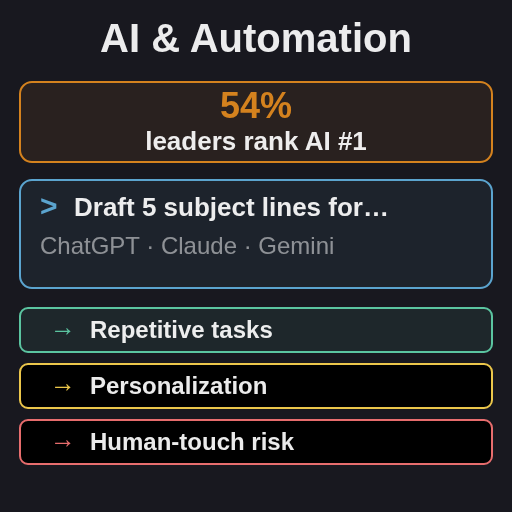

## Search & Paid Ads

- `SEO: keywords, links, indexability`
- PPC: bidding for quick quality leads
- SEO × SEM synergy lifts impact
- Precise targeting by behavior, intent
- Track ROAS, ROI, conversion rates

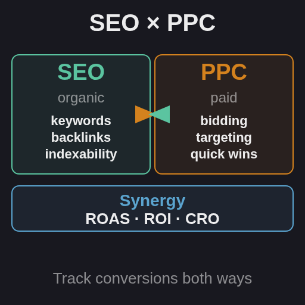

## Content & Video

- `91% of brands use video now`
- Deliver value before the sale
- Distribute across social, email, partners
- Editorial calendar drives cadence
- Lead magnets: ebooks, toolkits, guides

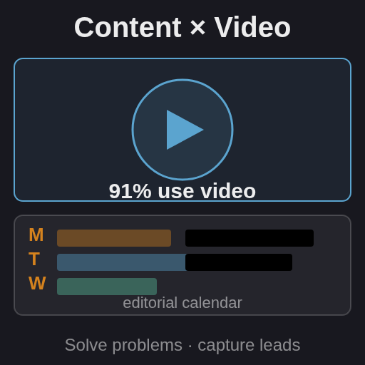

## Data & UX

- `Analysts surface revenue opportunities`
- GA4 powers actionable insights
- UX keeps every touchpoint seamless
- Consistent visuals: ads → landing
- A/B test pages and email elements

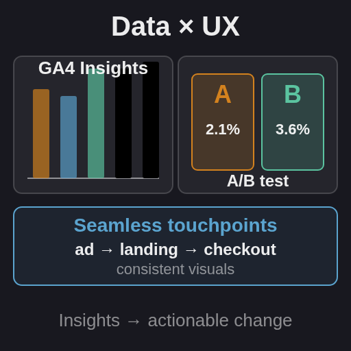

## Soft Skills

- `60% of employers value soft more`
- Lead, communicate, think strategically
- Strong soft skills get promoted faster
- Growth mindset pivots on feedback
- Teamwork stands out at interviews

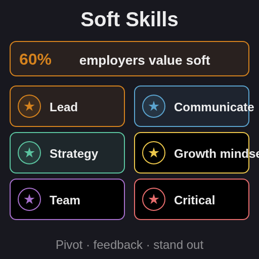

## Future-Proofing

- `Visual storytelling with charts, video`
- Interpret KPIs to spot trends early
- Cross-functional aligns with business
- Social branding builds clear identity
- Community engagement earns trust

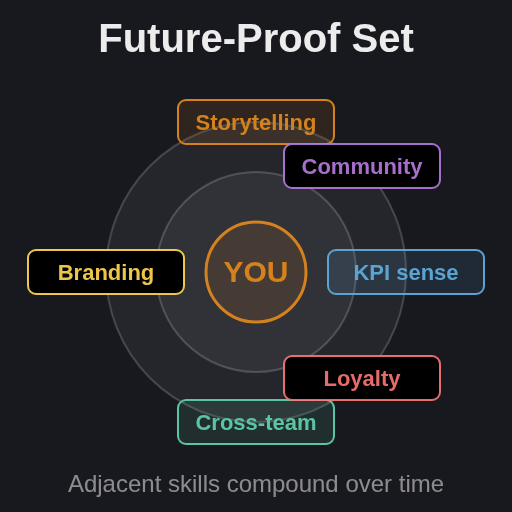

## Career Roles

- `Marketing Manager: brand-wide strategy`
- Social Manager: presence and service
- Growth: experiments scale the funnel
- T-shaped: deep in one, broad across
- Email Specialist: nurture and drip

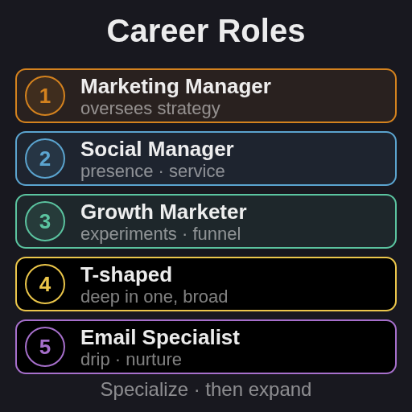

## Get Started

- `Build a personal brand and portfolio`
- Network at meetups, LinkedIn groups
- Learn ROI, CTR, persona vocabulary
- Earn a certification to validate skill
- Follow Search Engine Journal, Sprout

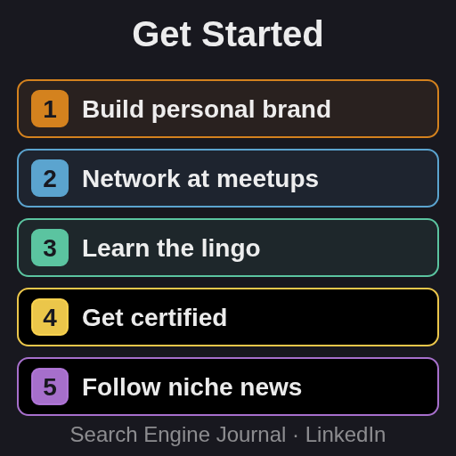